# Part2_Presentation slides

## Hotel Booking Exploration

### by Sanan Yahyazade

### Structure of dataset

There are 119390 bookings in the dataset with 32 features. Most variables are categoric in nature.

### Main features of interest in dataset

I'm most interested in figuring out which features are affects on potential tourists booking behavior.

### Features in the dataset will help support investigation

I expect that, planned travel time, hotel type and price will affect tourists' booking behavior

## Multivariate exploration

### Cancelation rate over the month

#### What was the percentage of cancelation over the months for different hotel types?

Graph shows that, cancelation rate are much higher in city hotels than resort hotels. Different aspects could affect this result such as number of bookings and price per person.

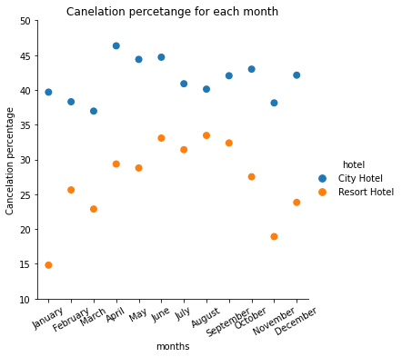

### Number of booking over the month

#### How number of bookings changes over the month for each hotel type ?

Here we can see that, number of bookings are higher in city hotels than resort hotels which might affect the cancelation rate.

[figure not shown]

### Cancelation Rate vs Number of Booking

#### What is the relation between booking number and cancelation rate ?

Number of bookings and cancelation rate are positively correlated. It indicates that, high booking numbers in hotels, will increase cancelation rate.

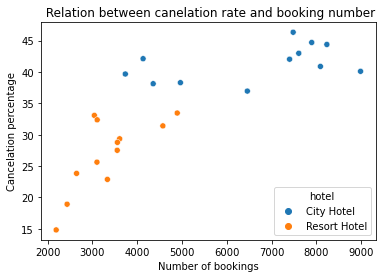

### Price Per Person vs Number of Guests

#### how number of visitors affects price per person in both hotel types?

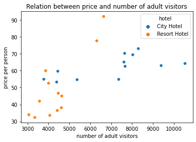

### Price Per Person vs Cancelaton rate

#### How price per person affects the cancelation rate ?

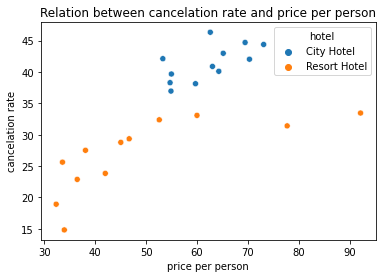

[output not shown]